# 04B Phylogenetic Tree Inspection & Rooting

sophiaaredas

2025-03-18

# Goals

1. Load the fastree unrooted tree.
2. Add tree to phyloseq object.
3. Visualize and inspect tree with ggtree.
4. Prune ASVs, if needed.
5. Root our tree.
6. Combine new tree with a phyloseq object.
7. Save 2 phyloseq objects: 1. Unrooted tree phyloseq object, 2. Rooted tree phyloseq object.

# Before you start

## Set my seed

```r
# Any number can be chosen
set.seed(238428)
```

## Load Packages

```r
pacman::p_load(tidyverse, phyloseq, ggtree, phytools, tidytree,
               install = FALSE)
```

## Load Data files

```r
# Preprocessed phyloseq object
load("data/03_PreProcessing/raw_preprocessed_physeq.RData")
raw_preprocessed_physeq
```

```
## phyloseq-class experiment-level object
## otu_table()   OTU Table:         [ 2605 taxa and 89 samples ]
## sample_data() Sample Data:       [ 89 samples by 43 sample variables ]
## tax_table()   Taxonomy Table:    [ 2605 taxa by 9 taxonomic ranks ]
```

```r
# Load in the tree!
unrooted_tree <- read.tree("data/04_Phylogenetic_Tree/ASVs_unrooted.tree")
unrooted_tree
```

```
##
## Phylogenetic tree with 2605 tips and 2603 internal nodes.
##
## Tip labels:
##   ASV_1971, ASV_2876, ASV_2326, ASV_2157, ASV_2378, ASV_2912, ...
## Node labels:
##   , 0.709, 0.935, 0.663, 0.871, 0.998, ...
##
## Unrooted; includes branch length(s).
```

```r
str(unrooted_tree)
```

```
## List of 5
##  $ edge       : int [1:5207, 1:2] 2606 2607 2608 2609 2610 2611 2611 2610 2612 2612 ...
##  $ edge.length: num [1:5207] 0.00868 0.03126 0.00674 0.04741 0.12139 ...
##  $ Nnode      : int 2603
##  $ node.label : chr [1:2603] "" "0.709" "0.935" "0.663" ...
##  $ tip.label  : chr [1:2605] "ASV_1971" "ASV_2876" "ASV_2326" "ASV_2157" ...
##  - attr(*, "class")= chr "phylo"
##  - attr(*, "order")= chr "cladewise"
```

# Merge Phyloseq

```r
# Intuition check
stopifnot(ntaxa(raw_preprocessed_physeq) == ntaxa(unrooted_tree))

# Merge the tree with the phyloseq object
unrooted_physeq <-
  merge_phyloseq(raw_preprocessed_physeq, unrooted_tree)
```

[output not shown]

[output not shown]

[output not shown]

[output not shown]

[output not shown]

[output not shown]

[output not shown]

[output not shown]

[output not shown]

[output not shown]

[output not shown]

[output not shown]

[output not shown]

[output not shown]

```r
unrooted_physeq
```

```
## phyloseq-class experiment-level object
## otu_table()   OTU Table:         [ 2605 taxa and 89 samples ]
## sample_data() Sample Data:       [ 89 samples by 43 sample variables ]
## tax_table()   Taxonomy Table:    [ 2605 taxa by 9 taxonomic ranks ]
## phy_tree()    Phylogenetic Tree: [ 2605 tips and 2603 internal nodes ]
```

# Plot Tree with `ggtree`

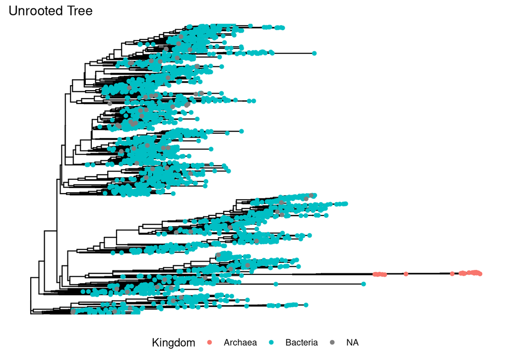

```r
# Make a basic tree
kingdom_tree <-
  ggtree(unrooted_physeq) +
  # color tips by kingdom
  geom_tippoint(mapping = aes(color = Kingdom)) +
#  scale_color_manual(values = c("goldenrod1", "cornflowerblue", "grey")) +
  # Add title
  labs(title = "Unrooted Tree") +
  #move the legend to the bottom
  theme(legend.position = "bottom"); kingdom_tree
```

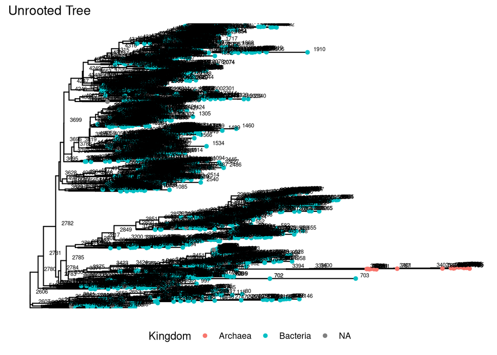

```r
kingdom_node_tree <-
  kingdom_tree +
  # Add the node label
  geom_text(aes(label=node), hjust= -0.5, vjust = -0.3, size = 2)
kingdom_node_tree
```

## Root tree from Archaea

If you do not have Archaea in your dataset, please skip this section and go to line 232 so that you can midroot your tree

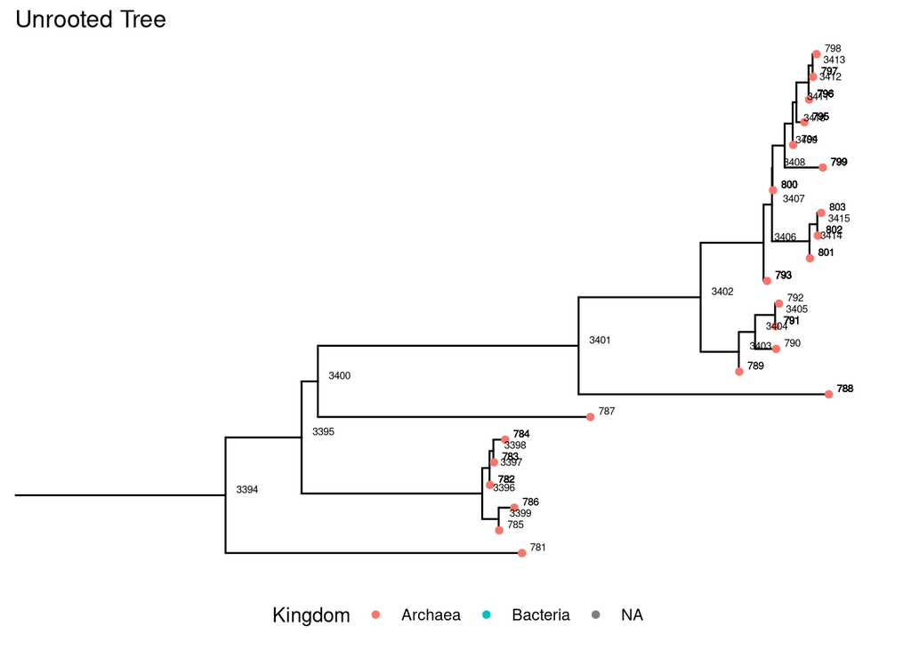

```r
# but first find the ASVs that are Archaea
archaea_node <- tax_table(raw_preprocessed_physeq) %>%
  as.data.frame() %>%
  filter(Kingdom == "Archaea") %>%
  pull(ASV)

# find the node that encompasses all Archaea
archaea_node <- findMRCA(unrooted_tree, tips = archaea_node, type = "node") # node = 3394

# View clade to check it out
viewClade(kingdom_node_tree, 3394)
```

```r
# Root the tree using node 3394
archaea_root_tree <- ape::root(unrooted_tree, node = 3394, resolve.root = TRUE)

# Check if tree is rooted
is.rooted(archaea_root_tree) # should be TRUE
```

```
## [1] TRUE
```

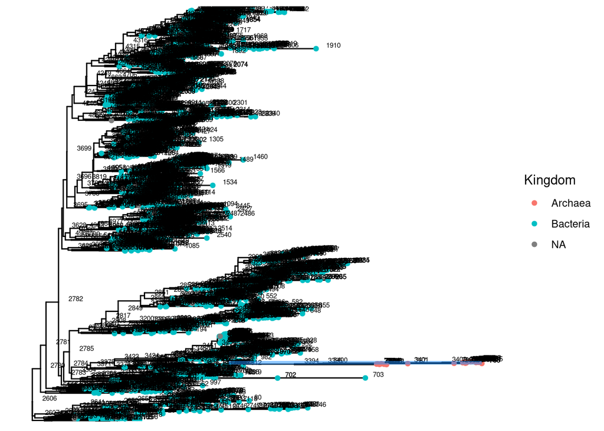

```r
# plot unrooted tree with node 3394 highlighted
archaea_tree <-
  ggtree(unrooted_physeq) +
  geom_tippoint(mapping = aes(color=Kingdom),
                size = 1.5) +
  geom_text(aes(label = node), hjust = -0.7, vjust = -0.2, size = 2) +
  geom_highlight(node = 3394, fill = "dodgerblue")

archaea_tree
```

```r
# merge with physeq
archaea_root_physeq <- merge_phyloseq(raw_preprocessed_physeq, archaea_root_tree)
```

[output not shown]

[output not shown]

[output not shown]

[output not shown]

[output not shown]

[output not shown]

[output not shown]

[output not shown]

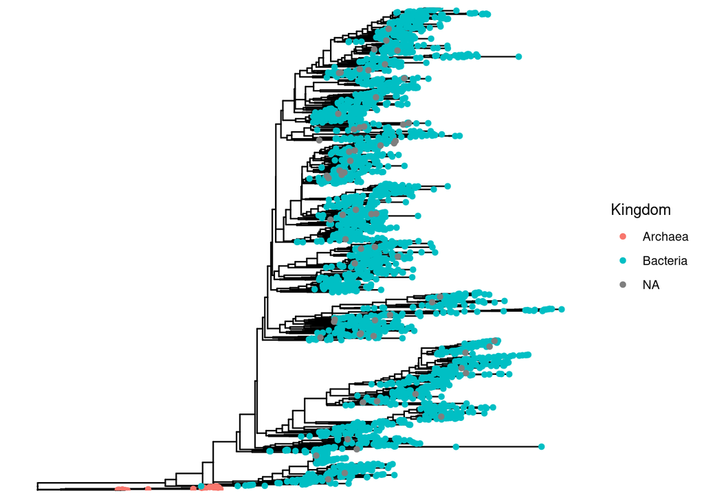

```r
# Plot rooted simple tree with no text
archaea_rooted_simple <- ggtree(archaea_root_physeq) +
  geom_tippoint(aes(color = Kingdom))

archaea_rooted_simple
```

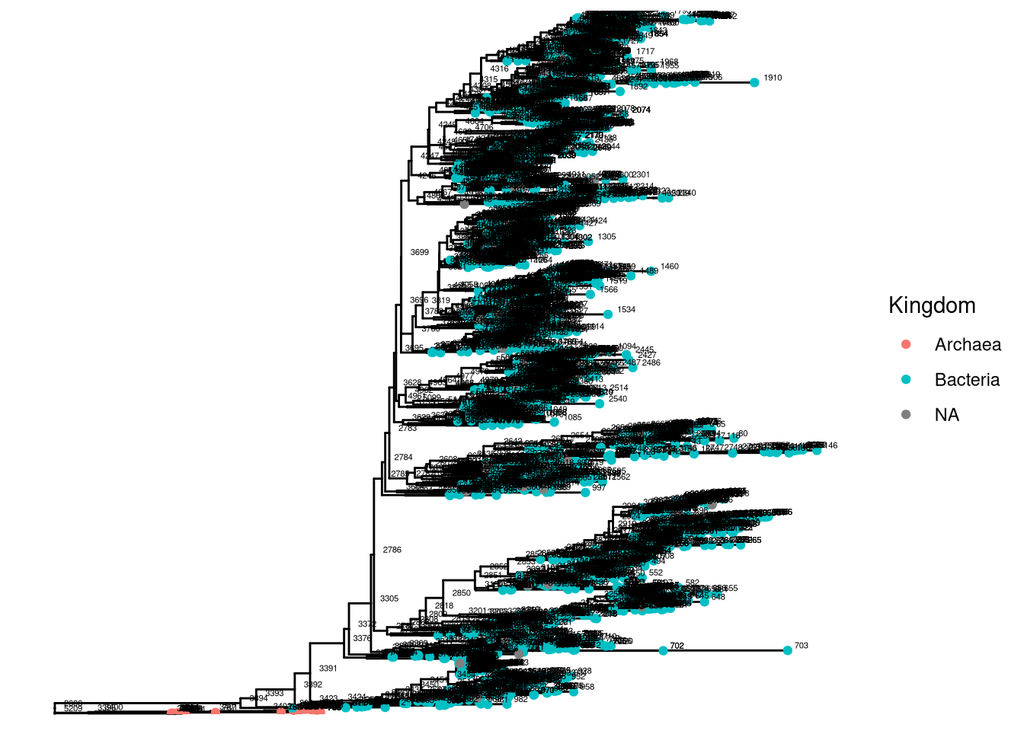

```r
# Plot rooted tree with text
archaea_rooted_text <- ggtree(archaea_root_physeq) +
  geom_tippoint(aes(color = Kingdom)) +
  geom_text(aes(label = node), hjust = -0.5, vjust = -0.3, size = 1.5)

archaea_rooted_text
```

First we loaded in our unrooted tree. Because we have Archaea we will want to root from there.

## Evaluate Long Branches

This part will get a little manual

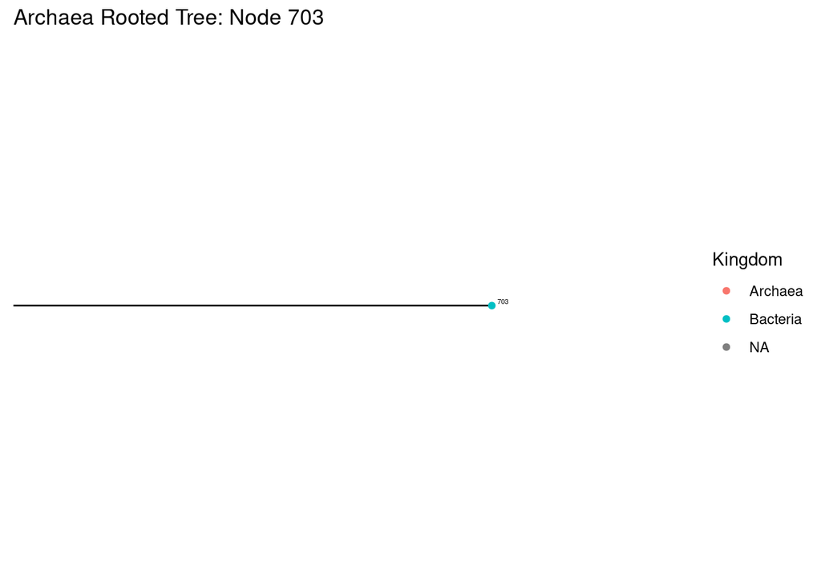

```r
# View a specific clade

# Zoom in on node that looks potentially suspicious
viewClade(archaea_rooted_text +
          labs(title = "Archaea Rooted Tree: Node 703"),
          node = 703)
```

```r
# Lets see its ancestors
ancestor(archaea_root_tree, 703)
```

```
##  [1] 3316 3310 3309 3308 3307 3306 3305 3372 3376 3391 3392 3393 3394 2606
```

```r
# Or if there are two nodes that we can see we can find its MRCA
## create tibble of tree to identify offspring
tree_tib <- as_tibble(archaea_root_physeq@phy_tree)

# lets look at the really long branch with a bunch of NAs
MRCA(archaea_root_tree, .node1 = 703, .node2 = 711) #3309
```

```
## [1] 3309
```

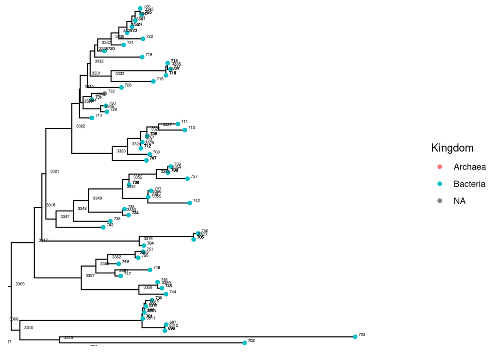

```r
viewClade(archaea_rooted_text, 3309)
```

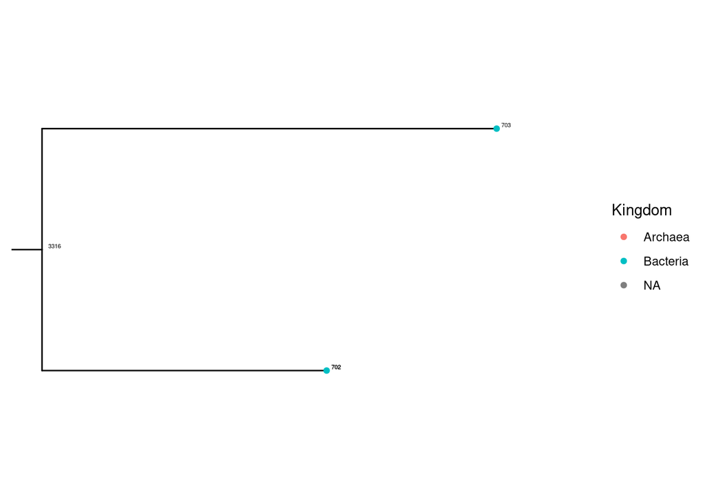

```r
# Actually we see the node 3316 is better that has the long node 703
viewClade(archaea_rooted_text, 3316)
```

```r
## create dataframe to view ASVs and taxa info and to pull the ASVs
node3316 <- offspring(tree_tib, 3316, tiponly = TRUE) %>%
  as.data.frame() %>% pull(label)

node3316_df <- as.data.frame(archaea_root_physeq@tax_table) %>% filter(ASV %in% node3316) %>% filter(Kingdom == "Bacteria" | is.na(Kingdom))

# look at counts of each phylum
node3316_df %>%
  count(Kingdom)
```

```
##    Kingdom n
## 1 Bacteria 2
```

```r
# look at counts of the ASVs
archaea_root_physeq %>%
  subset_taxa(., ASV == "ASV_2618") %>%
  otu_table() %>%
  data.frame() %>%
  colSums()
```

[output not shown]

[output not shown]

[output not shown]

[output not shown]

```
## X20210602.MA.ABB1F X20210602.MA.ABB1P X20210602.MA.ABB1W X20210602.MA.ABS1F
##                  0                  0                  0                  0
## X20210602.MA.ABS1P X20210602.MA.ABS1W X20210602.MA.CEB1F X20210602.MA.CEB1P
##                  0                  0                  0                  0
## X20210602.MA.CEB1W X20210602.MA.CES1F X20210602.MA.CES1P X20210602.MA.CES1W
##                  0                  0                  0                  0
## X20210602.MA.CWB1F X20210602.MA.CWB1P X20210602.MA.CWB1W X20210602.MA.CWS1F
##                  0                  0                  0                  0
## X20210602.MA.CWS1P X20210602.MA.CWS1W X20210602.MA.MBB1F X20210602.MA.MBB1P
##                  0                  0                  0                  0
## X20210602.MA.MBB1W X20210602.MA.MBS1F X20210602.MA.MBS1P X20210602.MA.MBS1W
##                  0                  0                  0                  0
## X20210602.MA.SCB1F X20210602.MA.SCB1P X20210602.MA.SCB1W X20210602.MA.SCS1F
##                  0                  0                  0                  0
## X20210602.MA.SCS1P X20210602.MA.SCS1W X20210615.MA.ABB2F X20210615.MA.ABB2P
##                  0                  0                  0                  0
## X20210615.MA.ABB2W X20210615.MA.ABS1F X20210615.MA.ABS1P X20210615.MA.ABS1W
##                  0                  0                  0                  0
## X20210615.MA.CEB1F X20210615.MA.CEB1P X20210615.MA.CEB1W X20210615.MA.CES1F
##                  0                  0                  0                  0
## X20210615.MA.CES1P X20210615.MA.CES1W X20210615.MA.CWB1F X20210615.MA.CWB1P
##                  0                  0                  0                  0
## X20210615.MA.CWB1W X20210615.MA.CWS1F X20210615.MA.CWS1P X20210615.MA.CWS1W
##                  0                  0                  0                  0
## X20210615.MA.MBB1F X20210615.MA.MBB1P X20210615.MA.MBB1W X20210615.MA.MBS1F
##                  0                  0                  0                  0
## X20210615.MA.MBS1P X20210615.MA.MBS1W X20210615.MA.SCB2P X20210615.MA.SCB2W
##                  0                  0                  2                  0
## X20210615.MA.SCS2F X20210615.MA.SCS2P X20210615.MA.SCS2W X20211005.MA.ABB2F
##                  0                  0                  0                  0
## X20211005.MA.ABB2P X20211005.MA.ABB2W X20211005.MA.ABS1F X20211005.MA.ABS1P
##                  0                  0                  0                  0
## X20211005.MA.ABS1W X20211005.MA.CEB1F X20211005.MA.CEB1P X20211005.MA.CEB1W
##                  0                  0                  0                  0
## X20211005.MA.CES2F X20211005.MA.CES2P X20211005.MA.CES2W X20211005.MA.CWB1F
##                  0                  0                  0                  0
## X20211005.MA.CWB1P X20211005.MA.CWB1W X20211005.MA.CWS1F X20211005.MA.CWS1P
##                  0                  0                  0                  0
## X20211005.MA.CWS1W X20211005.MA.MBB1F X20211005.MA.MBB1P X20211005.MA.MBB1W
##                  0                  0                  0                  0
## X20211005.MA.MBS1F X20211005.MA.MBS1P X20211005.MA.MBS1W X20211005.MA.SCB1F
##                  0                  0                  0                  0
## X20211005.MA.SCB1P X20211005.MA.SCB1W X20211005.MA.SCS2F X20211005.MA.SCS2P
##                  0                  0                  0                  0
## X20211005.MA.SCS2W
##                  0
```

```r
# Lets BLAST our sequences to investigate if they are real or not
node3316_df
```

```
##           Kingdom Phylum Class Order Family Genus Species      ASV
## ASV_1917 Bacteria   <NA>  <NA>  <NA>   <NA>  <NA>    <NA> ASV_1917
## ASV_2618 Bacteria   <NA>  <NA>  <NA>   <NA>  <NA>    <NA> ASV_2618
##                                                                                                                                                                                                                                                        ASVseqs
## ASV_1917 GAGGGGCGAGCGTTATTCGGAATGATTGGGCGTAAAGAGCACGTAGACGGTGAGTGTGCT…
## ASV_2618 GAGGGGCAAGCGTTGACCGGAATGACTGGGCGTAAAGAACACGTAGGCTGGAATCTTGGC…
```

We see that the two ASVs that are in our sample. ASV_1917 is node 702 and ASV_2618 is the longer node that is node 703

Our tree looks legitimate and we do not need to remove ASVs that were found in node 3316. BLASTing the two ASVs found that node 703 is long but it is a real ASV. Thus we do not need to remove anything.

We accidentally did too good of a job at removing contaminants in the previous step:)

## Prune your tree

Note that our tree actually looks quite nice and we do not need to prune any ASVs out. But if you find in your own data set that you have ASVs that need to be removed here is the code for how to do that!

```r
# Function from Joey McMurdie: https://github.com/joey711/phyloseq/issues/652
pop_taxa = function(physeq, badTaxa){
  allTaxa <-  taxa_names(physeq)
  allTaxa <- allTaxa[!(allTaxa %in% badTaxa)]
  return(prune_taxa(allTaxa, physeq))}

# Let's use the pop_taxa function :)
# Recreate a phyloseq object without your unwanted ASV or node
# Lets use an arbitrary ASV
archaea_physeq_rmASV2618 <-
  archaea_root_physeq %>%
  pop_taxa(., "ASV_2618")

# Intuition Check
ntaxa(archaea_root_physeq) - ntaxa(archaea_physeq_rmASV2618)

# Visually inspect
ggtree(archaea_physeq_rmASV2618) +
  geom_tippoint(mapping = aes(color = Kingdom))
```

Note: this is just an example of how to remove one ASV. In our case ASV_2618 is not a bad ASV and in fact it is real.

## Plot Archaea rooted final tree

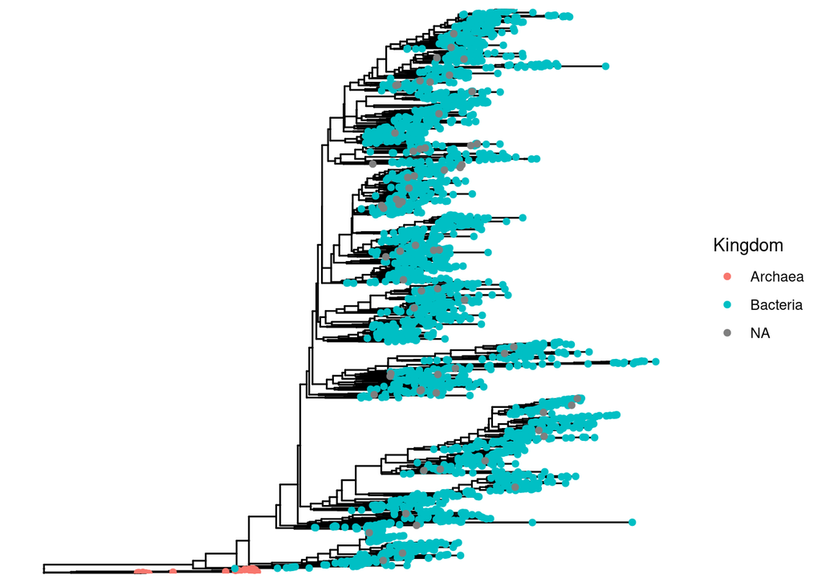

```r
# Plot rooted simple tree with no text
archaea_rooted_simple <- ggtree(archaea_root_physeq) +
  geom_tippoint(aes(color = Kingdom))

archaea_rooted_simple
```

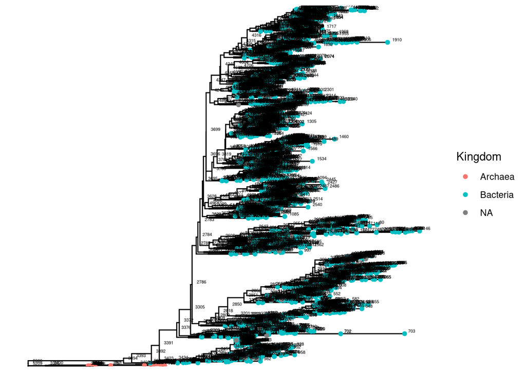

```r
# Plot rooted tree with text
archaea_rooted_text <- ggtree(archaea_root_physeq) +
  geom_tippoint(aes(color = Kingdom)) +
  geom_text(aes(label = node), hjust = -0.5, vjust = -0.3, size = 1.5)

archaea_rooted_text
```

Now we can go on and save to a new phyloseq object. Continue to line 280.

## Midrooting your tree

If your project’s data does not have Archaea or a specified outgroup you can midroot your tree. Midpoint rooting calculates tip to tip distances and then places the root halfway between the two longest tips.

**Do not complete this step if you have Archaea in your data set**

**If you need to midroot your tree:** 1. investigate and pull the ASVs in your long branches and BLAST to confirm if these are real bacterial ASVs.

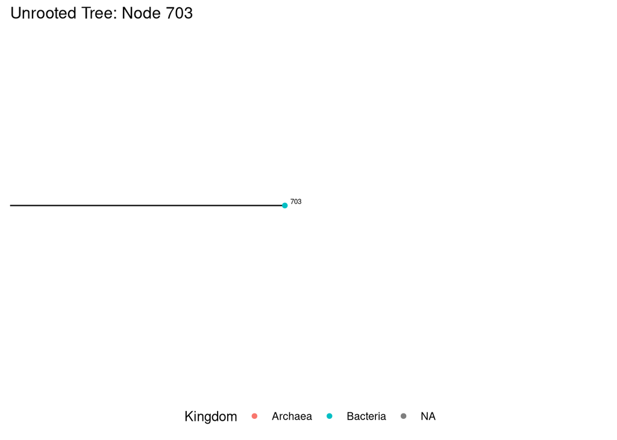

```r
# View a specific clade

# Zoom in on node that looks potentially suspicious
viewClade(kingdom_node_tree +
          labs(title = "Unrooted Tree: Node 703"),
          node = 703)
```

```r
# Lets see its ancestors
ancestor(unrooted_tree, 703)
```

```
##  [1] 3315 3309 3308 3307 3306 3305 3304 2785 2784 2783 2782 2781 2780 2606
```

```r
# Or if there are two nodes that we can see we can find its MRCA
## create tibble of tree to identify offspring
tree_tib_unroot <- as_tibble(unrooted_physeq@phy_tree)

# lets look at the really long branch with a bunch of NAs
MRCA(unrooted_tree, .node1 = 703, .node2 = 702) #3315
```

```
## [1] 3315
```

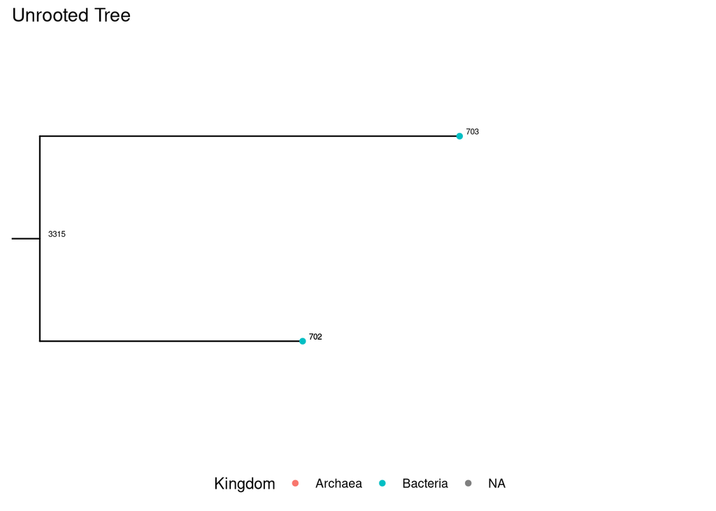

```r
viewClade(kingdom_node_tree, 3315)
```

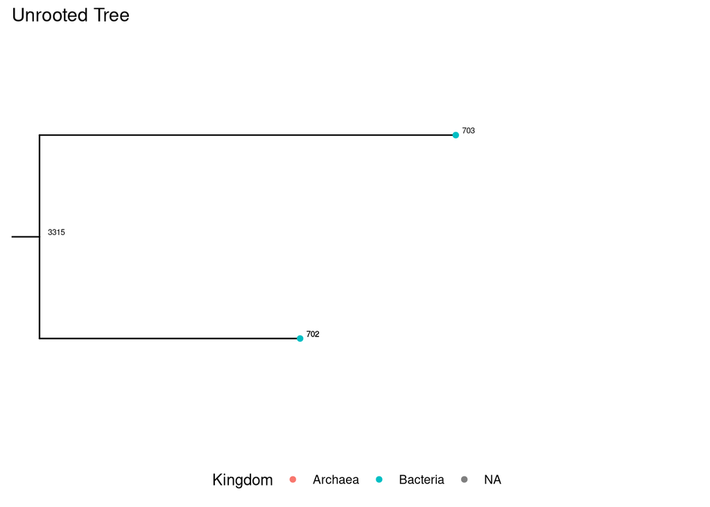

```r
# Actually we see the node 3316 is better that has the long node 703
viewClade(kingdom_node_tree, 3315)
```

```r
## create dataframe to view ASVs and taxa info and to pull the ASVs
node3315_unrooted <- offspring(tree_tib_unroot, 3315, tiponly = TRUE) %>%
  as.data.frame() %>% pull(label)

node3315_unrooted_df <- as.data.frame(archaea_root_physeq@tax_table) %>% filter(ASV %in% node3315_unrooted) %>% filter(Kingdom == "Bacteria" | is.na(Kingdom))

# look at counts of each phylum
node3315_unrooted_df %>%
  count(Kingdom)
```

```
##    Kingdom n
## 1 Bacteria 2
```

```r
# look at counts of the ASVs
unrooted_physeq %>%
  subset_taxa(., ASV == "ASV_2618") %>%
  otu_table() %>%
  data.frame() %>%
  colSums()
```

[output not shown]

[output not shown]

[output not shown]

[output not shown]

```
## X20210602.MA.ABB1F X20210602.MA.ABB1P X20210602.MA.ABB1W X20210602.MA.ABS1F
##                  0                  0                  0                  0
## X20210602.MA.ABS1P X20210602.MA.ABS1W X20210602.MA.CEB1F X20210602.MA.CEB1P
##                  0                  0                  0                  0
## X20210602.MA.CEB1W X20210602.MA.CES1F X20210602.MA.CES1P X20210602.MA.CES1W
##                  0                  0                  0                  0
## X20210602.MA.CWB1F X20210602.MA.CWB1P X20210602.MA.CWB1W X20210602.MA.CWS1F
##                  0                  0                  0                  0
## X20210602.MA.CWS1P X20210602.MA.CWS1W X20210602.MA.MBB1F X20210602.MA.MBB1P
##                  0                  0                  0                  0
## X20210602.MA.MBB1W X20210602.MA.MBS1F X20210602.MA.MBS1P X20210602.MA.MBS1W
##                  0                  0                  0                  0
## X20210602.MA.SCB1F X20210602.MA.SCB1P X20210602.MA.SCB1W X20210602.MA.SCS1F
##                  0                  0                  0                  0
## X20210602.MA.SCS1P X20210602.MA.SCS1W X20210615.MA.ABB2F X20210615.MA.ABB2P
##                  0                  0                  0                  0
## X20210615.MA.ABB2W X20210615.MA.ABS1F X20210615.MA.ABS1P X20210615.MA.ABS1W
##                  0                  0                  0                  0
## X20210615.MA.CEB1F X20210615.MA.CEB1P X20210615.MA.CEB1W X20210615.MA.CES1F
##                  0                  0                  0                  0
## X20210615.MA.CES1P X20210615.MA.CES1W X20210615.MA.CWB1F X20210615.MA.CWB1P
##                  0                  0                  0                  0
## X20210615.MA.CWB1W X20210615.MA.CWS1F X20210615.MA.CWS1P X20210615.MA.CWS1W
##                  0                  0                  0                  0
## X20210615.MA.MBB1F X20210615.MA.MBB1P X20210615.MA.MBB1W X20210615.MA.MBS1F
##                  0                  0                  0                  0
## X20210615.MA.MBS1P X20210615.MA.MBS1W X20210615.MA.SCB2P X20210615.MA.SCB2W
##                  0                  0                  2                  0
## X20210615.MA.SCS2F X20210615.MA.SCS2P X20210615.MA.SCS2W X20211005.MA.ABB2F
##                  0                  0                  0                  0
## X20211005.MA.ABB2P X20211005.MA.ABB2W X20211005.MA.ABS1F X20211005.MA.ABS1P
##                  0                  0                  0                  0
## X20211005.MA.ABS1W X20211005.MA.CEB1F X20211005.MA.CEB1P X20211005.MA.CEB1W
##                  0                  0                  0                  0
## X20211005.MA.CES2F X20211005.MA.CES2P X20211005.MA.CES2W X20211005.MA.CWB1F
##                  0                  0                  0                  0
## X20211005.MA.CWB1P X20211005.MA.CWB1W X20211005.MA.CWS1F X20211005.MA.CWS1P
##                  0                  0                  0                  0
## X20211005.MA.CWS1W X20211005.MA.MBB1F X20211005.MA.MBB1P X20211005.MA.MBB1W
##                  0                  0                  0                  0
## X20211005.MA.MBS1F X20211005.MA.MBS1P X20211005.MA.MBS1W X20211005.MA.SCB1F
##                  0                  0                  0                  0
## X20211005.MA.SCB1P X20211005.MA.SCB1W X20211005.MA.SCS2F X20211005.MA.SCS2P
##                  0                  0                  0                  0
## X20211005.MA.SCS2W
##                  0
```

```r
# Lets BLAST our sequences to investigate if they are real or not
node3315_unrooted_df
```

```
##           Kingdom Phylum Class Order Family Genus Species      ASV
## ASV_1917 Bacteria   <NA>  <NA>  <NA>   <NA>  <NA>    <NA> ASV_1917
## ASV_2618 Bacteria   <NA>  <NA>  <NA>   <NA>  <NA>    <NA> ASV_2618
##                                                                                                                                                                                                                                                        ASVseqs
## ASV_1917 GAGGGGCGAGCGTTATTCGGAATGATTGGGCGTAAAGAGCACGTAGACGGTGAGTGTGCT…
## ASV_2618 GAGGGGCAAGCGTTGACCGGAATGACTGGGCGTAAAGAACACGTAGGCTGGAATCTTGGC…
```

ASV_2618 = suspect. Let’s explore this ASV more!

When we BLASTed we see that both hits are legit bacteria 16S hits. Therefore, the rest of our tree looks good and we do not need to remove anything.

### Midroot our tree

```r
# Is the tree rooted?
new_unrooted_tree <- phy_tree(unrooted_tree)

# Check to see if tree is rooted.. expect it to be false
is.rooted(new_unrooted_tree)
```

```
## [1] FALSE
```

```r
# Let's midpoint root the tree
midpoint_rooted_tree <- midpoint.root(new_unrooted_tree)

# Is the new tree rooted? Should be TRUE!
is.rooted(midpoint_rooted_tree)
```

```
## [1] TRUE
```

```r
#Assign to a new phyloseq object: merging subsetted phyloseq with the new rooted tree

# We will be merging our phyloseq object that has been midrooted. Below is an example of how to create the phyloseq object removing your bad taxa and then saving it to a new phyloseq object.

# Merge tree with our raw_preprocessed physeq
midpoint_rooted_physeq <- merge_phyloseq(raw_preprocessed_physeq, midpoint_rooted_tree)
```

[output not shown]

[output not shown]

[output not shown]

[output not shown]

[output not shown]

[output not shown]

[output not shown]

[output not shown]

```r
# This is extra code that we will not be using in class but may be useful to you in your own data analysis:)
# 1. Create the phyloseq object without bad ASV
physeq_rm2618 <-
  raw_preprocessed_physeq %>%
  subset_taxa(ASV != "ASV_2618")

# Merge tree with the new physeq_rm456
midroot_physeq_rm2618 <-
  merge_phyloseq(physeq_rm2618, midpoint_rooted_tree)
```

[output not shown]

[output not shown]

[output not shown]

[output not shown]

[output not shown]

[output not shown]

[output not shown]

```r
midroot_physeq_rm2618
```

```
## phyloseq-class experiment-level object
## otu_table()   OTU Table:         [ 2604 taxa and 89 samples ]
## sample_data() Sample Data:       [ 89 samples by 43 sample variables ]
## tax_table()   Taxonomy Table:    [ 2604 taxa by 9 taxonomic ranks ]
## phy_tree()    Phylogenetic Tree: [ 2604 tips and 2603 internal nodes ]
```

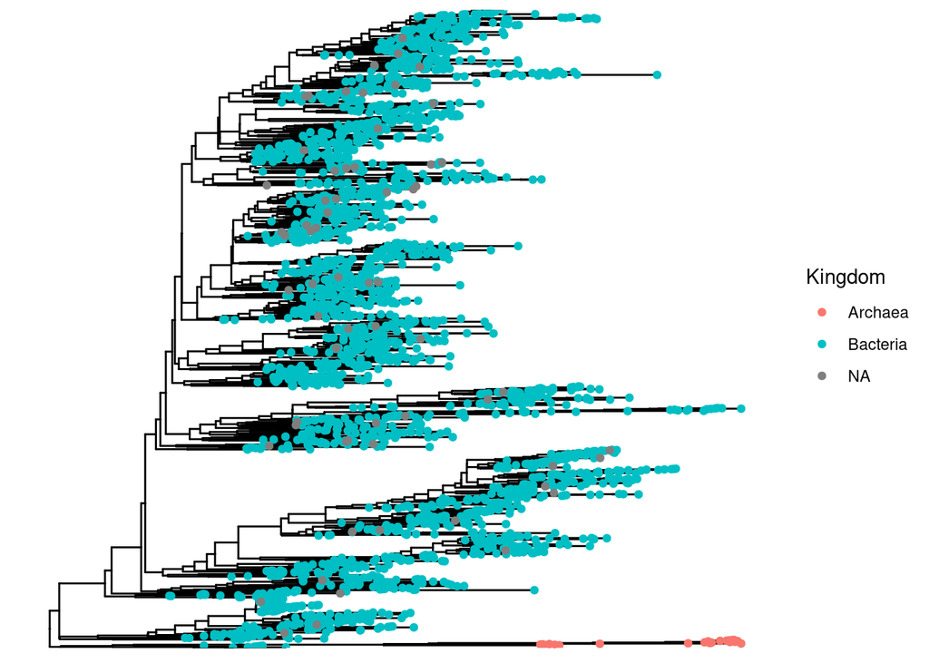

```r
# Quick inspection of tree
ggtree(midroot_physeq_rm2618) +
  geom_tippoint(mapping = aes(color = Kingdom))
```

Now that we have midrooted our tree, lets view our final tree

## Plot Final Midrooted Tree

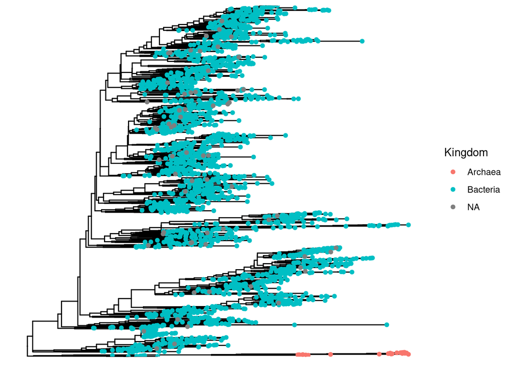

```r
#View our final tree

# Plot midrooted simple tree with no text
mid_rooted_simple <- ggtree(midpoint_rooted_physeq) +
  geom_tippoint(aes(color = Kingdom))

mid_rooted_simple
```

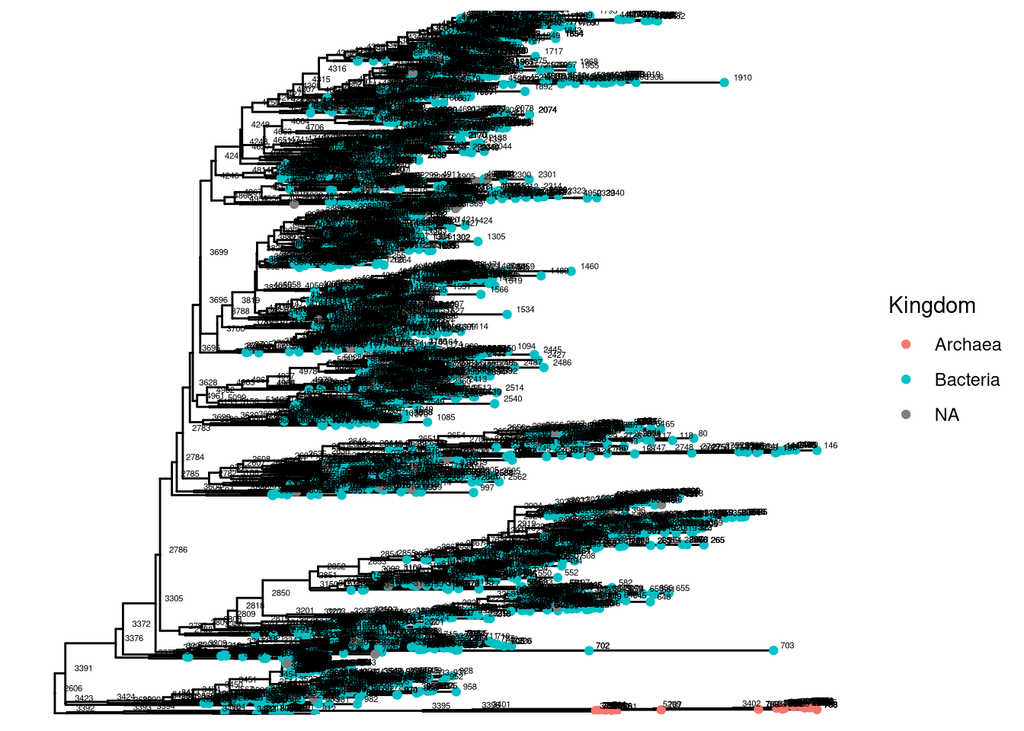

```r
# Plot rooted tree with text
mid_rooted_text <- ggtree(midpoint_rooted_physeq) +
  geom_tippoint(aes(color = Kingdom)) +
  geom_text(aes(label = node), hjust = -0.5, vjust = -0.3, size = 1.5)

mid_rooted_text
```

## Save phyloseq object

Note that because I have not removed any taxa, I will take my archaea_root_physeq and rename it into phytree_preprocessed_physeq object. If you have rooted your tree using the midroot, then please use your midroot_physeq object and save that into phytree_preprocessed_physeq.

If you have removed your bad taxa and have midrooted your tree please note lines 269-271. These lines will be commented out but serve to provide you an understanding of how we can save our phyloseq objects with our midrooted tree.

```r
# lets rename our phyloseq object
phytree_preprocessed_physeq <- archaea_root_physeq

# Save both phyloseq objects with our tree object to one .RData file
# save(list = c("unrooted_physeq_rm2618", "midroot_physeq_rm2618"),
#      file = "data/04_Phylogenetic_Tree/phytree_preprocessed_physeq.RData")


# now lets save our preprocessed phyloseq object
save(phytree_preprocessed_physeq, file = "data/04_Phylogenetic_Tree/phytree_preprocessed_physeq.RData")
```

Now that we have our tree, we can go forth and begin our next analysis!